# Отчёт по лабораторной работе №5

Аппарат сетей Петри

Автор

принадлежность

Малюга Валерия Васильевна

Российский университет дружбы народов

# 1 Цель работы

# 2 Задание

- Создать рабочий каталог для кода.
- Установить необходимые пакеты.
- Выполнить предложенный код.
- Преобразовать код в литературный стиль.
- Сгенерировать из литературного кода:
  - чистый код;
  - jupyter notebook;
  - документацию в формате Quarto.
- Выполнить код из jupyter notebook.
- Интегрировать документацию в формате Quarto в отчёт.
- Добавить в код в литературном стиле вычисление для набора параметров.
- Сгенерировать из литературного кода с параметрами:
  - чистый код;
  - jupyter notebook;
  - документацию в формате Quarto.
- Выполнить код из jupyter notebook с параметрами.
- Выполнить дополнительные задания.
- Интегрировать документацию с параметрами в формате Quarto в отчёт.
- Результирующие файлы выложить на git.

# 3 Теоретическое введение

## 3.1 Общая информация

Сеть Петри была предложена Карлом Адамом Петри в 1962 году [1]. Это математический аппарат для моделирования дискретных систем. Графически она представляется как двудольный ориентированный граф двух типов вершин: позиции (круги) и переходы (прямоугольники).

- Позиции (Places) суть пассивные элементы, описывающие состояние системы (например, наличие ресурса или выполнение условия). Внутри позиции могут находиться фишки (tokens) — неотрицательное целое число, указывающее на количество ресурсов.
- Переходы (Transitions) суть активные элементы, описывающие события или действия системы. Они могут срабатывать, изменяя состояние модели.
- Дуги (Arcs) суть направленные соединения между позициями и переходами (но не между двумя позициями или двумя переходами), которые показывают, как состояние влияет на события и наоборот.
- Маркировка (Marking) есть распределение фишек по позициям в определённый момент времени, то есть текущее состояние модели. Смена маркировок происходит при срабатывании переходов в соответствии с определёнными правилами. Теория сетей Петри, появившаяся как инструмент для анализа химических процессов, сегодня является мощным и наглядным математическим аппаратом. Она незаменима везде, где нужно описать параллельные, асинхронные и распределённые системы. В её основе лежат всего четыре элемента, а богатство поведения возникает из их комбинации.

### 3.1.1 Формальное определение

Сеть Петри (N-схема) — это четвёрка: 𝑁 = (𝑃, 𝑇, 𝐹, 𝑀0), где: - 𝑃 = 𝑝1, 𝑝2, …, 𝑝𝑛 — конечное множество позиций (мест); - 𝑇 = 𝑡1, 𝑡2, …, 𝑡𝑚 — конечное множество переходов; - 𝐹 ⊆ (𝑃 × 𝑇 ) ∪ (𝑇 × 𝑃) — множество дуг (отношения инцидентности); - 𝑀0 ∶ 𝑃 → ℕ — маркировка, задающая начальное распределение фишек.

## 3.2 Обедающие философы

### 3.2.1 Классическая постановка

За круглым столом сидят N философов (обычно 5). Перед каждым философом стоит тарелка с едой. Между каждыми двумя соседними философами лежит одна вилка (или палочка для еды). Таким образом, количество вилок равно количеству философов. Задача была сформулирована Эдсгером Дейкстрой в 1965 году как иллюстрация проблемы синхронизации в параллельных вычислительных системах [2].

### 3.2.2 Основные положения

1. Правила поведения философов:
- Философ может находиться в одном из трёх состояний: думает, голоден (хочет есть), ест.
- Чтобы поесть, философу необходимы две вилки — та, что слева от него, и та, что справа.
- Если философ не может получить обе вилки одновременно, он ждёт, пока они освободятся.
- Поев, философ кладёт обе вилки обратно на стол и возвращается к размышлениям.
2. Ограничения:
- Вилками нельзя пользоваться одновременно двум философам.
- Философ не может отнять вилку у соседа — только дождаться, пока тот её положит.

### 3.2.3 Проблема взаимной блокировки (deadlock)

При наивной реализации (каждый философ сначала берёт левую вилку, затем правую) возникает тупиковая ситуация: если все философы одновременно возьмут левую вилку, то каждый будет ждать правую, которая уже занята соседом. В результате никто не может поесть — система замирает. Это и есть взаимная блокировка, подробно описанная в [3].

Для предотвращения deadlock предложены различные подходы:

- Арбитр (официант) — вводится дополнительный процесс, который разрешает есть не более чем N-1 философам одновременно.
- Асимметричное правило — философы с нечётным номером сначала берут левую вилку, затем правую, а чётные — наоборот.
- Атомарный захват — философ берёт обе вилки одновременно (если они свободны) иначе не берёт ни одной.
- Использование мьютексов и условных переменных в программных реализациях.

# 4 Выполнение лабораторной работы

## 4.1 Выполнение предложенных скриптов

Были созданы и выполнены все предложенные скрипты.

При выполнении скрипта dining_philosophers.jl были получены:

1. Анализ (подтвердилось, что при моделировании калссической задачи обедающих философов происходит блокировка, а при модифицированной с арбитром блокировки нет (рис. 1)).

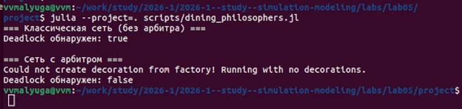

Рисунок 1: Выполнение скрипта dining_philosophers.jl

2. Два графика, на которых видны изменения маркировок во времени по обеим моделям(рис. 2): классической и с арбитром. Видно, что в классической модели (рис. 3) спустя время все философы становятся голодными и никто не ест: происходит блокировка. В модели с арбитром (рис. 4) видно, как постоянно меняются состояния у философов и блокировка не происходит .

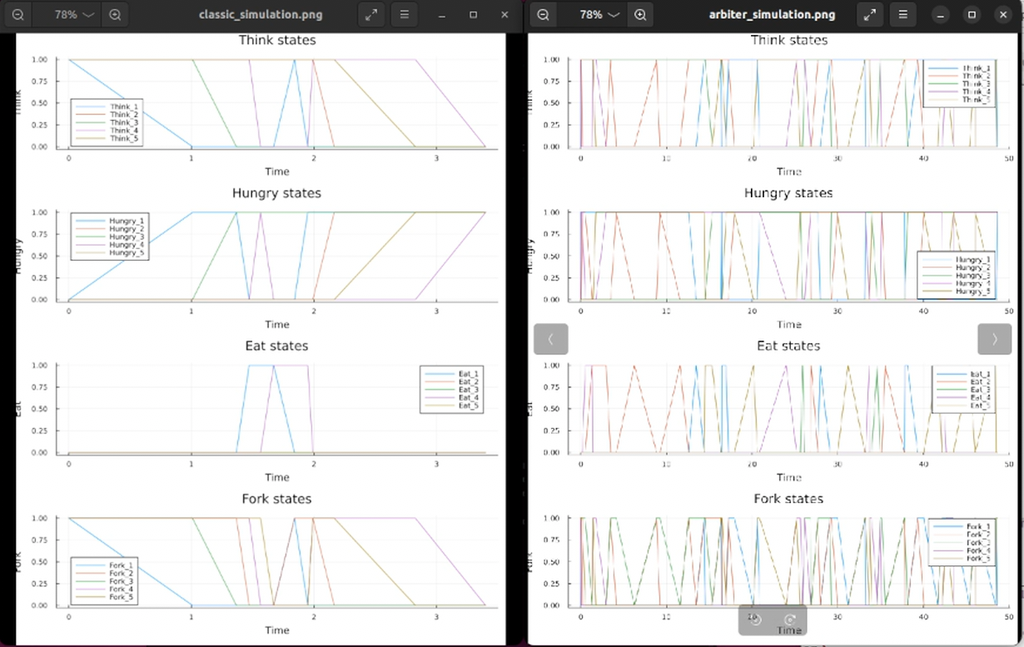

Рисунок 2: Полученные графики после выполнения dining_philosophers.jl

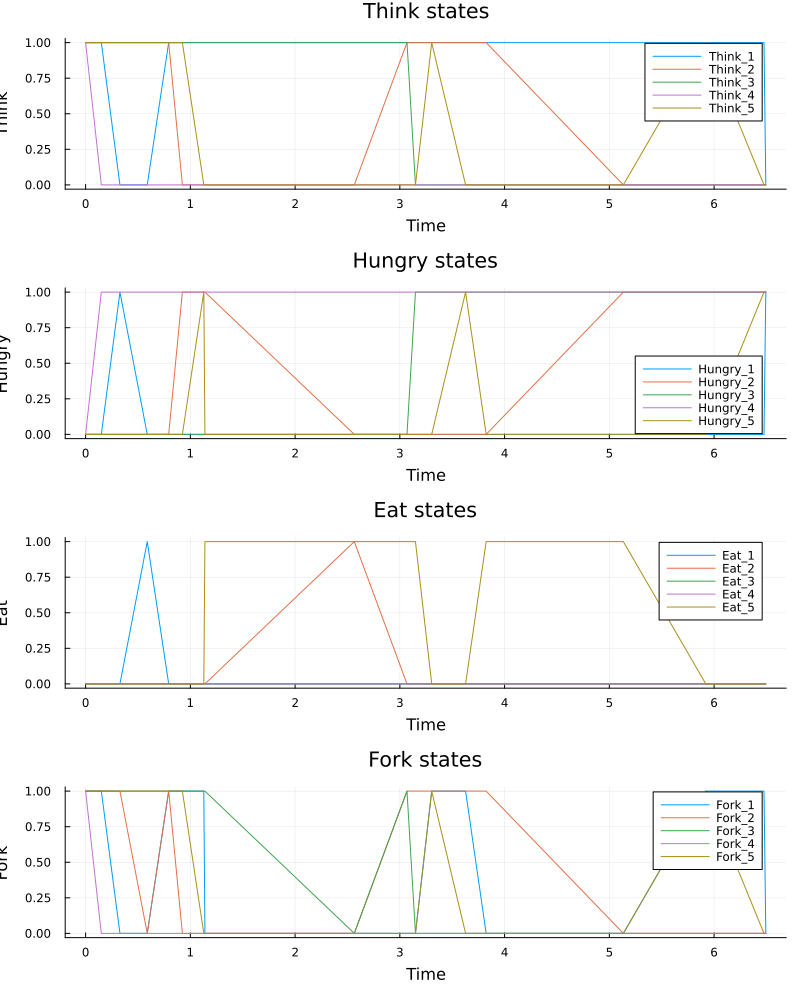

Рисунок 3: График классической модели

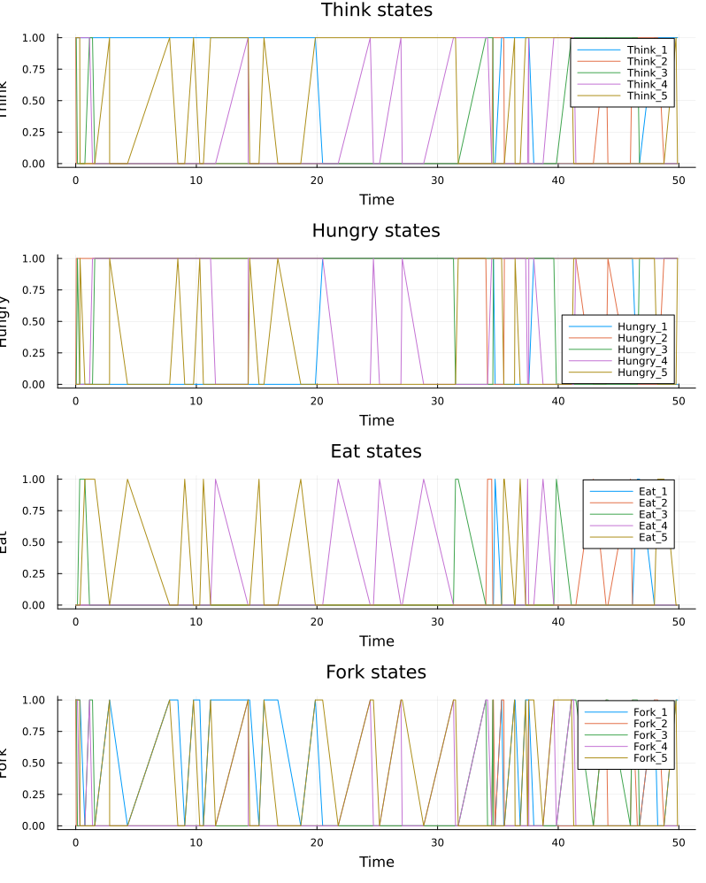

3. Две таблицы dining_classic и dining_arbiter, в которых отображены изменения маркировок состоний для каждого философа (0 или 1) в течение времени(рис. 5, рис. 6).

[figure not shown]

Рисунок 5: Таблица dining_classic

[figure not shown]

Рисунок 6: Таблица dining_arbiter

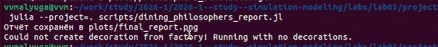

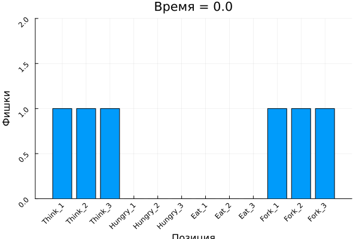

Рисунок 8: Анимация philosophers_simulation.gif

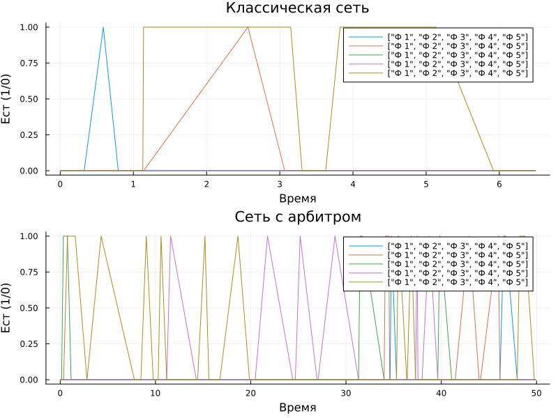

Рисунок 9: Финальный график

## 4.2 Преобразование в литературный код

Предложенные скрипты были преобразованы в литературный код(рис. 10, рис. 11, рис. 12).

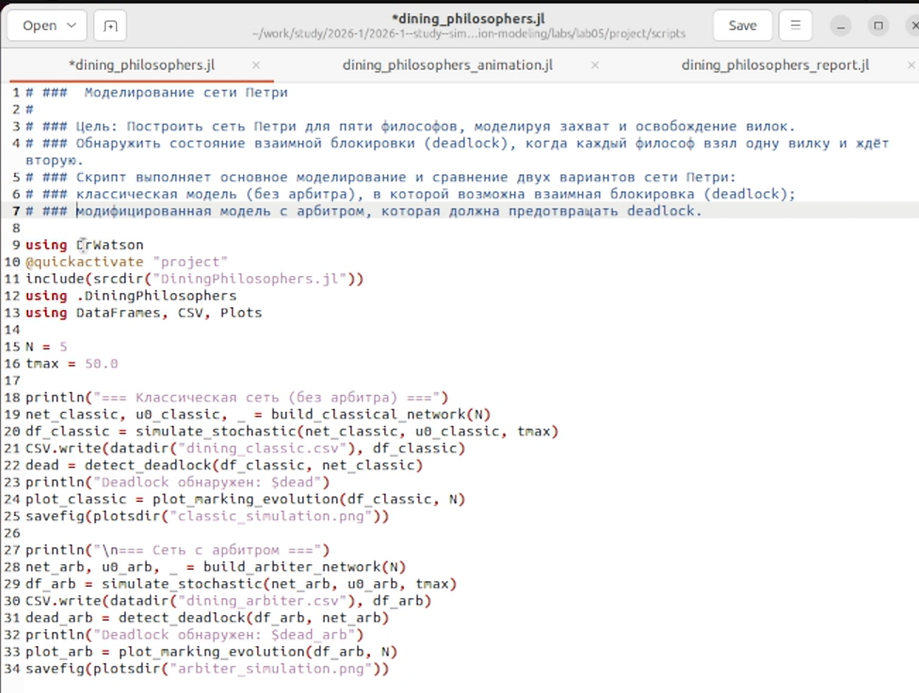

Рисунок 10: Преобразование в литературный код dining_philosophers.jl

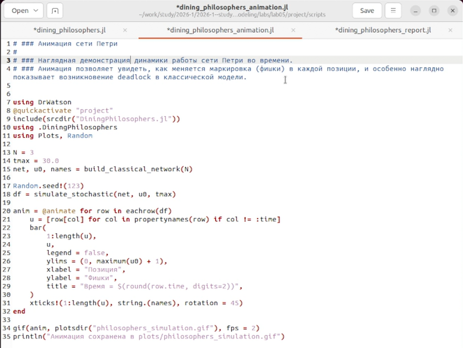

Рисунок 11: Преобразование в литературный код dining_philosophers_animation.jl

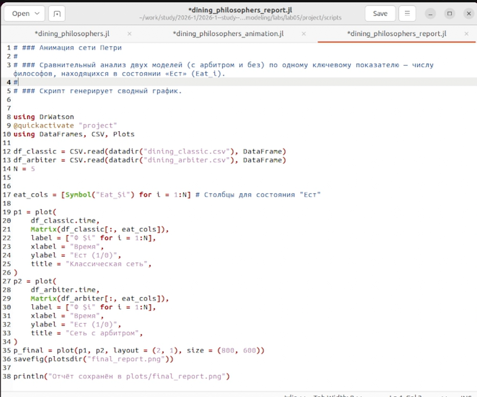

Рисунок 12: Преобразование в литературный код dining_philosophers_report.jl

В итоге получила каталог с необходимы скриптами (рис. 13).

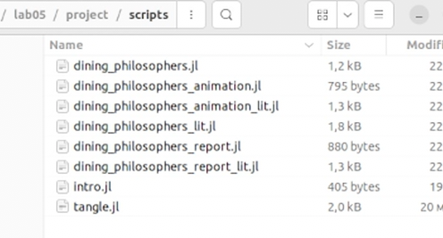

Рисунок 13: Каталог скриптов проекта

## 4.3 Преобразование в производные форматы

После преобразования в литературный код из скриптов были получены производные форматы с помощью скрипта tangle.jl (рис. 14).

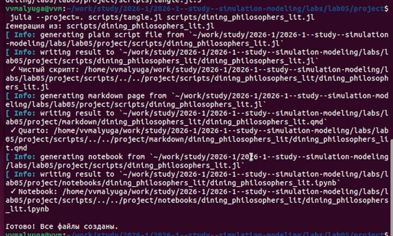

Рисунок 14: Получение производных форматов

Были проверены полученные ноутбуки на наличие ошибок (рис. 15).

[figure not shown]

Рисунок 15: Ноутбук dining_philosophers_lit

## 4.4 Реализия скриптов

### 4.4.1 Моделирование сети Петри

Цель: Построить сеть Петри для пяти философов, моделируя захват и освобождение вилок. Обнаружить состояние взаимной блокировки (deadlock), когда каждый философ взял одну вилку и ждёт вторую.

Скрипт выполняет основное моделирование и сравнение двух вариантов сети Петри: классическая модель (без арбитра), в которой возможна взаимная блокировка (deadlock); модифицированная модель с арбитром, которая должна предотвращать deadlock.

```
  Activating project at `~/work/study/2026-1/2026-1--study--simulation-modeling/labs/lab05/project`
=== Классическая сеть (без арбитра) ===
Deadlock обнаружен: true
Could not create decoration from factory! Running with no decorations.
```

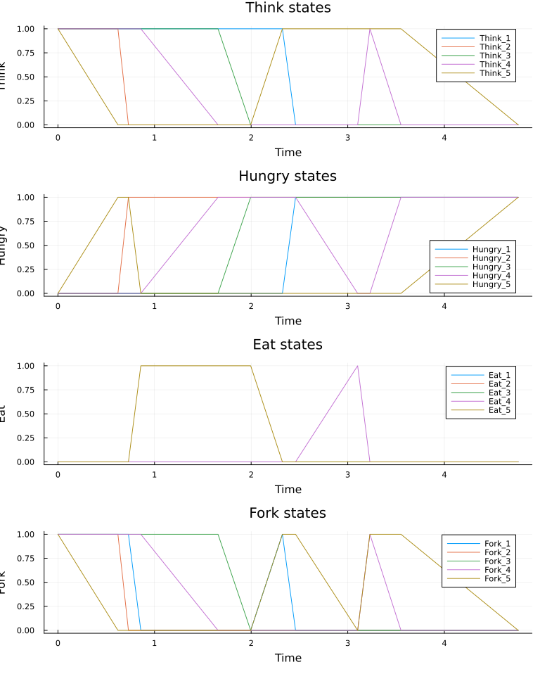

```julia
using Pkg
Pkg.activate(joinpath(dirname(@__FILE__), "..", "project"))
Pkg.instantiate()

using DrWatson
using DataFrames, CSV
using Plots
gr()


include(srcdir("DiningPhilosophers.jl"))
using .DiningPhilosophers

N = 5
tmax = 50.0

println("=== Классическая сеть (без арбитра) ===")
net_classic, u0_classic, _ = build_classical_network(N)
df_classic = simulate_stochastic(net_classic, u0_classic, tmax)
CSV.write(datadir("dining_classic.csv"), df_classic)
dead = detect_deadlock(df_classic, net_classic)
println("Deadlock обнаружен: $dead")
plot_classic = plot_marking_evolution(df_classic, N)
savefig(plot_classic, plotsdir("classic_simulation.png"))

plot_classic
```

```
=== Сеть с арбитром ===
Deadlock обнаружен: false
```

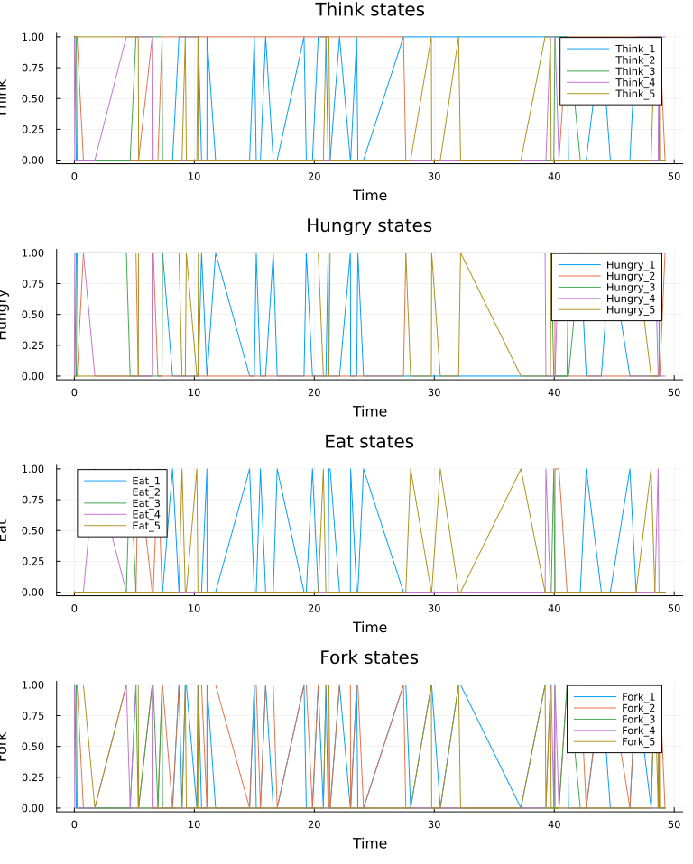

```julia
println("\n=== Сеть с арбитром ===")
net_arb, u0_arb, _ = DiningPhilosophers.build_arbiter_network(N)
df_arb = DiningPhilosophers.simulate_stochastic(net_arb, u0_arb, tmax)
CSV.write(datadir("dining_arbiter.csv"), df_arb)
dead_arb = DiningPhilosophers.detect_deadlock(df_arb, net_arb)
println("Deadlock обнаружен: $dead_arb")
plot_arb = DiningPhilosophers.plot_marking_evolution(df_arb, N)
savefig(plot_arb, plotsdir("arbiter_simulation.png"))
plot_arb
```

### 4.4.2 Анимация сети Петри

Наглядная демонстрация динамики работы сети Петри во времени. Анимация позволяет увидеть, как меняется маркировка (фишки) в каждой позиции, и особенно наглядно показывает возникновение deadlock в классической модели.

```julia
using Pkg
Pkg.activate(joinpath(dirname(@__FILE__), "..", "project"))
Pkg.instantiate()

using DrWatson
using DataFrames, CSV
using Plots
gr()

using DrWatson
using Plots, Random

include(srcdir("DiningPhilosophers.jl"))
using .DiningPhilosophers

N = 3
tmax = 30.0
net, u0, names = build_classical_network(N)

Random.seed!(123)
df = simulate_stochastic(net, u0, tmax)

anim = @animate for row in eachrow(df)
    u = [row[col] for col in propertynames(row) if col != :time]
    bar(
        1:length(u),
        u,
        legend = false,
        ylims = (0, maximum(u0) + 1),
        xlabel = "Позиция",
        ylabel = "Фишки",
        title = "Время = $(round(row.time, digits=2))",
    )
    xticks!(1:length(u), string.(names), rotation = 45)
end
nothing
gif(anim, plotsdir("philosophers_simulation.gif"), fps = 2)
println("Анимация сохранена в plots/philosophers_simulation.gif")
nothing
```

[output not shown]

### 4.4.3 Сравнительный анализ

Сравнительный анализ двух моделей (с арбитром и без) по одному ключевому показателю — числу философов, находящихся в состоянии «Ест» (Eat_i).

Скрипт генерирует сводный график.

```
  Activating project at `~/work/study/2026-1/2026-1--study--simulation-modeling/labs/lab05/project`
Could not create decoration from factory! Running with no decorations.
```

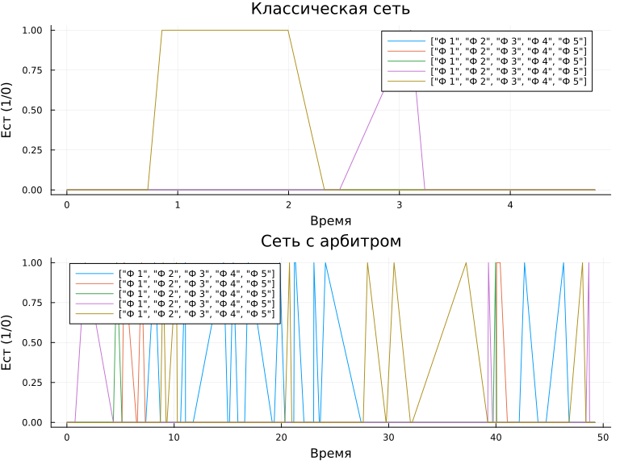

```julia
using Pkg
Pkg.activate(joinpath(dirname(@__FILE__), "..", "project"))
Pkg.instantiate()

using DrWatson
using DataFrames, CSV
using Plots
gr()


using DrWatson
using DataFrames, CSV
using Plots

df_classic = CSV.read(datadir("dining_classic.csv"), DataFrame)
df_arbiter = CSV.read(datadir("dining_arbiter.csv"), DataFrame)
N = 5

eat_cols = [Symbol("Eat_$i") for i = 1:N]

p1 = plot(
    df_classic.time,
    Matrix(df_classic[:, eat_cols]),
    label = ["Ф $i" for i = 1:N],
    xlabel = "Время",
    ylabel = "Ест (1/0)",
    title = "Классическая сеть",
)
p2 = plot(
    df_arbiter.time,
    Matrix(df_arbiter[:, eat_cols]),
    label = ["Ф $i" for i = 1:N],
    xlabel = "Время",
    ylabel = "Ест (1/0)",
    title = "Сеть с арбитром",
)
p_final = plot(p1, p2, layout = (2, 1), size = (800, 600))
savefig(p_final, plotsdir("final_report.png"))

p_final
```

```julia
println("Отчёт сохранён в plots/final_report.png")
```

```
Отчёт сохранён в plots/final_report.png
```

## 4.5 Анализ

Таким образом, полученные результаты полностью согласуются с теоретическими ожиданиями и подтверждают, что даже минимальная модификация (ограничение числа одновременно обедающих философов) способна исключить взаимную блокировку.

# 5 Выводы

В результате выполнения лабораторной работы №5 «Аппарат сетей Петри. Моделирование задачи „Обедающие философы“» были решены все поставленные задачи:

1. Построены две сети Петри для пяти философов: классическая (приводящая к deadlock) и с арбитром (предотвращающая deadlock).
2. Реализовано стохастическое моделирование с использованием алгоритма Гиллеспи; подтверждено возникновение взаимной блокировки в классической модели и её отсутствие в модели с арбитром.
3. Получены и проанализированы графики эволюции маркировок, сводный график состояния «Ест», а также создана анимация, наглядно иллюстрирующая динамику системы.
4. Код оформлен в стиле литературного программирования с использованием `Literate.jl`. Сгенерированы производные форматы: чистые скрипты, Jupyter Notebook и Quarto-документация.
5. Подготовлен отчёт в формате Quarto, содержащий все необходимые разделы, перекрёстные ссылки, библиографию и встроенные результаты моделирования. Отчёт успешно скомпилирован в форматы PDF, HTML и DOCX.
6. Рабочий репозиторий размещён на GitHub с соблюдением соглашения об именовании Denote, семантического версионирования и общепринятых коммитов.

**Итог:** Изучен математический аппарат сетей Петри как инструмент для анализа параллельных процессов. На примере задачи «Обедающие философы» показано, как формальная верификация позволяет выявить проблему deadlock и предложить простое, но эффективное решение. Полученные навыки могут быть применены при проектировании и анализе распределённых систем, баз данных и многопоточных приложений.

# Список литературы

1.

Petri C. A. Kommunikation mit Automaten. Schriften des Rheinisch-Westfälischen Institutes für instrumentelle Mathematik an der Universität Bonn, 1962.

2.

Dijkstra E. W. Hierarchical ordering of sequential processes // Acta Informatica. Springer, 1971. Т. 1, № 2. С. 115–138.

3.

Coffman Jr E. G., Elphick M. J., Shoshani A. System deadlocks // ACM Computing Surveys (CSUR). 1971. Т. 3, № 2. С. 67–78.